# Testing the batlikecall detector on some REAL DATA !!!

This notebook describes what happens when I run a pre-trained neural network model trained to predict the presence of batlike FM sweeps in a 10ms spectrogram image. In the previous notebook ('Building and running neural networks on batlike call data') I generated and trained a neural network. In this notebook I'm actually going to be running it on some *real* data to see how well it can deal with the realities of life...

```python
import keras
import matplotlib.pyplot as plt
plt.rcParams['agg.path.chunksize'] = 10000
import numpy as np
import scipy.io.wavfile as WAV
```

```python
# load a single channel 'busy' recording :
filename = 'ch0_2018-07-28_22-06-13_1532804773.wav'
fs, full_audio = WAV.read('wavs/'+filename)
fullaudio_norm = full_audio/(-1.0 + 2**15)
```

```python
%matplotlib notebook
```

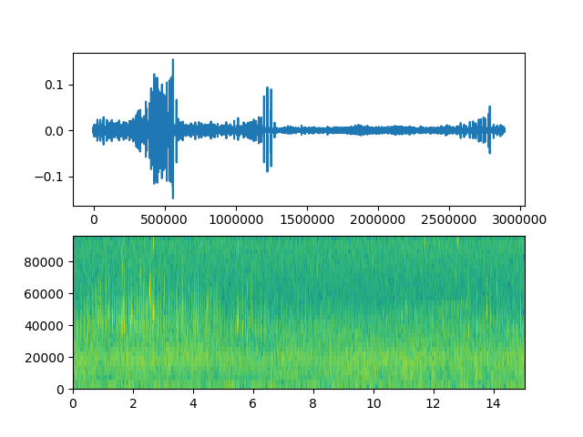

```python
plt.figure()
plt.subplot(211)
plt.plot(fullaudio_norm)
plt.subplot(212)
s,f,t,im = plt.specgram(fullaudio_norm, Fs=fs, NFFT=64, noverlap=40,)
```

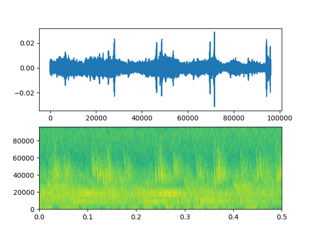

```python
# let's take only part of the recording so we can visualise the waveform and spectrograms in detail :
part_audionorm = fullaudio_norm[:96000]
plt.figure()
plt.subplot(211)
plt.plot(part_audionorm)
plt.subplot(212)
S,f,t,im = plt.specgram(part_audionorm, Fs=fs, NFFT=64, noverlap=32);
```

```python
S.shape
```

```
(33, 2999)
```

```python
2999/59.0
```

```
50.83050847457627
```

```python
# Now let's split the whole spectrogram into tinier 10ms segments, which is what the network was trained
n_images = 50
ncols = 59
nrows= 33

S_test = np.flipud(S[:,:n_images*ncols])
many_10msclips = np.zeros((n_images, nrows, ncols))
start_inds = np.arange(0,n_images*ncols-60, 60)

for i, start_index in enumerate(start_inds):
    end_index = start_index + 59
    many_10msclips[i,:,:] = S_test[:, start_index:end_index]
```

```python
def normalise_wref_tomax(X):
    max_norm  = (X+10**-15)/np.max(abs(X+10**-15))
    return(max_norm)
```

```python
# And now let's do the band-wise mean subtraction like we did before:
many10msclips_meansub = np.copy(many_10msclips)
from make_training_data import mean_subtract_rowwise
for i, each_image in enumerate(many_10msclips):
    many10msclips_meansub[i,:,:] = normalise_wref_tomax(mean_subtract_rowwise(each_image))
```

```python
# Now let's reshape the spectrograms into the required 1d shape, and see what the network predicts !!
manyclips_for_input = many10msclips_meansub.reshape(-1, nrows*ncols)

#load the pre-trained model:
network = keras.models.load_model('batlikecall_detector_v0.h5')
```

```python
probs = network.predict(manyclips_for_input)
```

## And so ... it looks like this quick-and-dirty network is actually capable of detecting real bat calls. Kind of encouraging !

### What was done :

The 0.5 second audio recording was split into non-overlapping 10millisecond segments. The spectrograms for each of these segments were calculated with 64 sample FFT window, 32 sample overlap. This gave rise to an image-like matrix of 33 x 59 dimensions. This was fed into the pre-trained network and the prediction confidence was plotted over the spectrogram itself.

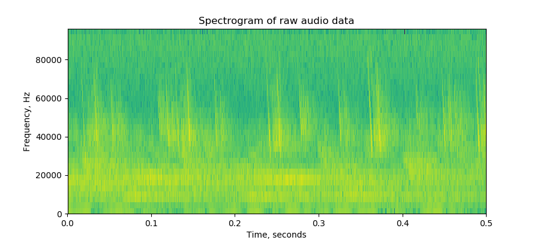

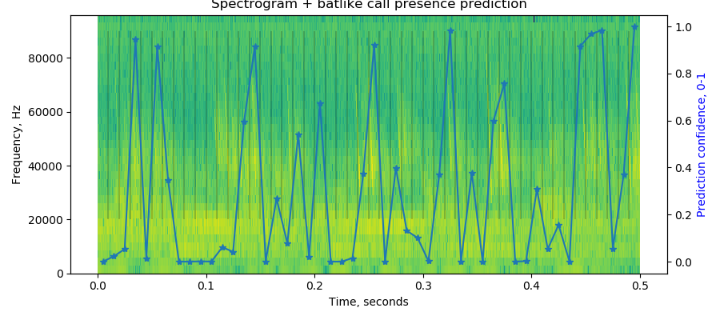

```
Text(0.5,1,'Spectrogram + batlike call presence prediction')
```

```python
plt.figure(figsize=(9,4))
plt.specgram(part_audionorm, Fs=fs, NFFT=64, noverlap=32);
plt.xlabel('Time, seconds')
plt.ylabel('Frequency, Hz')
plt.title('Spectrogram of raw audio data')

fig, ax1 = plt.subplots()
fig.set_figheight(4)
fig.set_figwidth(9)
S,f,t,im=plt.specgram(part_audionorm, Fs=fs, NFFT=64, noverlap=32)
for seg in np.arange(0.010,0.5,0.01):
    plt.vlines(seg,20000,90000, linewidth=0.25)
ax1.set_ylabel('Frequency, Hz')
ax1.set_xlabel('Time, seconds')

ax2 = ax1.twinx()
ax2.plot(np.linspace(0.005,0.495,probs[:,1].size), probs[:,1],'-*')
ax2.set_ylabel('Prediction confidence, 0-1', color='blue')
fig.tight_layout()
plt.title('Spectrogram + batlike call presence prediction')
```

### Concluding remarks : The bat call detector is *not* fantastic, buhuuuut - it does its job fairly okay, given the kind of training data it got. The training data was basically just FM chirps to show it what bat calls are like, and a few other sounds (white noise, upward ultrasonic chirps, downward audible chirps) to show it what bat calls are not like....and it's already able to predict the presence of a bat call over real recordings.

### Next steps :

- 1 : Increase the size + variation in the training data, consider multiharmonic bat calls, consider adding reverberation
- 2 : Instead of using non-overlapping audio segments to get presence/absence predictions, try using *overlapping* audio segments, this might generate a more continuous prediction of where the bat calls are in the audio data !
- 3 : Of course, ultimately it's best to have the network learn from *real* data that's been labelled manually, but to me this feels very cumbersome,given that I've already managed so much with purely synthesised data !!!